# Public Service Decline and Support for the Populist Right

Evidence from England’s National Health Service

Zachary P Dickson

London School of Economics and Political Science

# Research Question

- Two dominant explanations for populist right support:
  - **Economic backlash**: trade shocks, job losses, deindustrialisation (Margalit 2019)
  - **Cultural backlash**: immigration, value change, status threat (Norris and Inglehart 2019)
- Less attention to citizens’ *direct* experiences with the state through public services
- **This paper**: Does declining public service delivery fuel support for the populist right?
  - Do affected voters shift to the populist right — or to the mainstream opposition?
  - Is this conditioned by local immigration?

# Theory

- Public services are the most direct means through which citizens interact with and evaluate the state
- The **social contract**: citizens accept obligations (taxes, law) in exchange for core public services (Levi 1988; Besley 2020)
- When the state fails to deliver, dissatisfaction and grievances follow
  - Validates the populist right’s anti-establishment narrative (Mudde 2016)
- **Why the populist right — not the left?**
  - Frames service decline through an ethno-nationalist lens: “deserving natives” vs. “undeserving migrants”
  - Attributes NHS strain directly to immigrant overuse
  - Framing is more credible to voters in areas where immigration is actually higher

# Expectations

1. Exposure to GP practice closures **increases support for the populist right**
2. The effects are **stronger in areas with greater immigration**, where the populist right’s framing resonates more

## The British Context

- The **NHS** is a near-universal public service — virtually all citizens use it
  - Only ~12–14% of the population has private health insurance
  - A true *valence issue*: all parties back the NHS; voters demand more spending on it
- **NHS satisfaction** has declined to its lowest level in three decades
- GP practices are the **primary access point** to NHS care and specialized services
- The NHS has been a central issue in elections and the Brexit referendum

[figure not shown]

[figure not shown]

[figure not shown]

[figure not shown]

[figure not shown]

[figure not shown]

[figure not shown]

[figure not shown]

## NHS: Public Opinion

> **What sector should the UK government spend more on?**

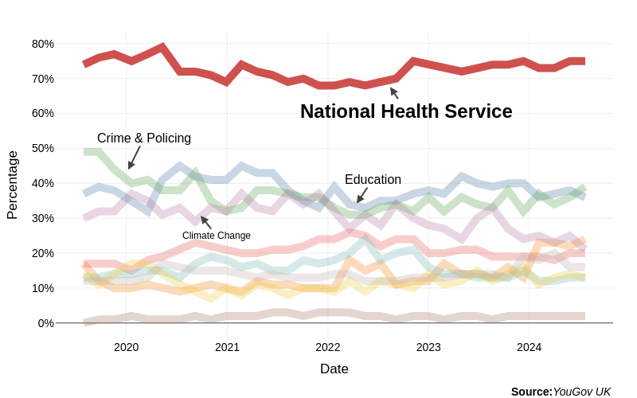

# GP Practice Closures

- Since 2013: nearly **1,700 GP practice closures** in England — ~25% of all public practices
- Over **600,000 patients** directly affected
- Closures are driven by staff shortages, retirements — *not* conventional austerity
- Remaining practices absorb displaced patients → longer waits, worse care
- Provides staggered, exogenous spatial and temporal variation

## Patients Required to Register at a New Practice

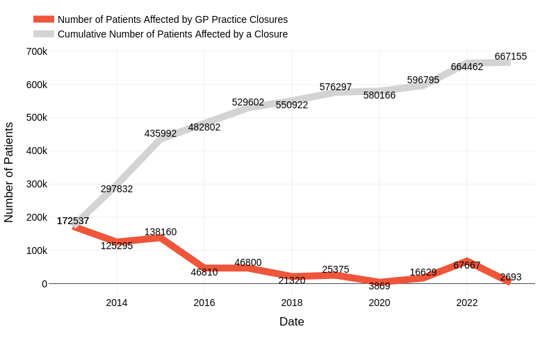

### From 2013-2024, 1,708 GP Practices Closed

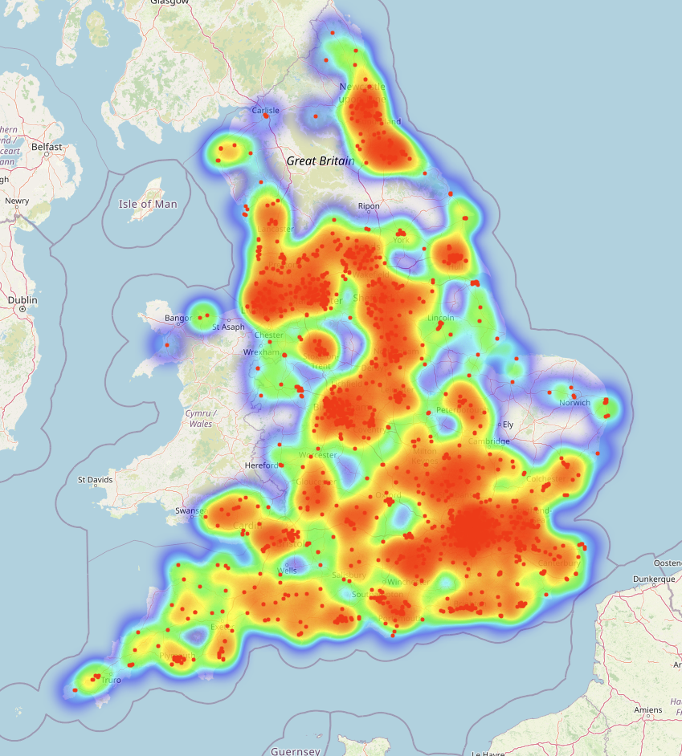

# Data

**Administrative & Survey Data**

- **NHS Digital**: universe of GP closures in England (2013–2023)
- **GP Patient Survey** (Ipsos): annual practice-level satisfaction for *every* GP practice in England
- **Understanding Society (USOC)**: ~30,000 households, 13 panel waves (2009–2022); restricted geo-linked version matched to GP catchment areas
- **British Election Study (BES)**: ~30,000 respondents, annual waves (2014–2023); geo-linked; used for independent replication

**Contextual & Communication Data**

- **ONS Local Migration**: annual international migration and migrant GP registrations by local authority
- **English Indices of Multiple Deprivation** + local unemployment (ONS)
- **Party press releases**: 2,775 UKIP press releases (2010–2024)
- **Party YouTube channels**: 736 UKIP + 517 Reform UK videos (2011–2024); full transcripts analyzed

# Research Design

**Identification**

**Estimation Strategies**

- **Primary**: Sun & Abraham (2021) cohort-average treatment effects — robust to heterogeneous treatment effects in staggered DiD
- **Robustness**: Matrix completion (Athey et al. 2021; Liu, Wang, and Xu 2022) as alternative counterfactual estimator
- **Moderation**: Binning estimator (Hainmueller, Mummolo, and Xu 2019) for conditional average treatment effects across levels of immigration, deprivation, unemployment

# Results

## Step 1: Do Closures Harm Patient Experiences?

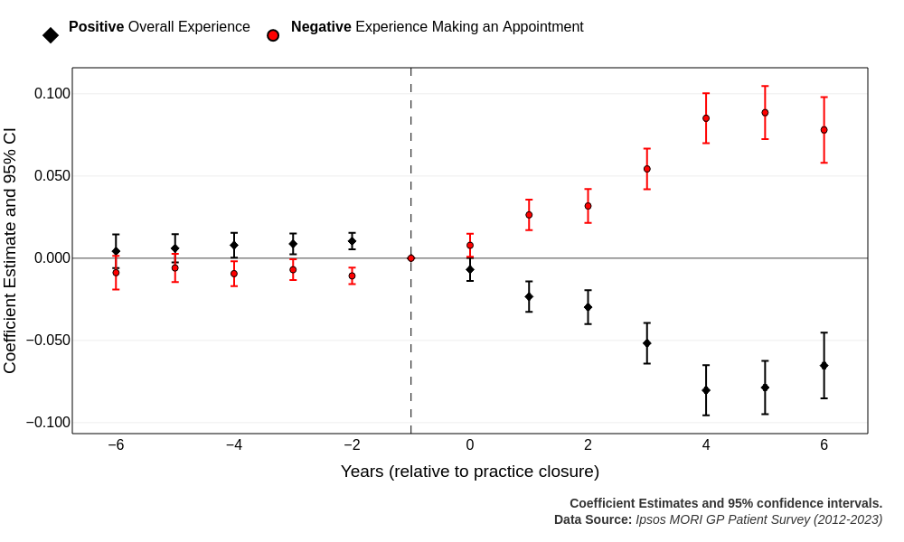

**Note:** Dynamic effects of a nearby closure on patient satisfaction at area GP practices. Black: % reporting positive overall experience (↓). Red: % reporting negative appointment experience (↑). Effects emerge immediately and persist 4–5 years.

## Step 2: Do Voters Shift to the Populist Right? (USOC)

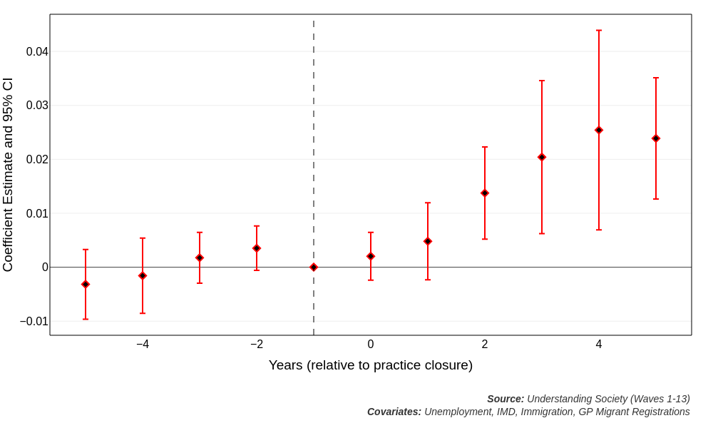

**Note:** Sun-Abraham event study, USOC panel (~30,000 households, 2009–2022). Respondent, area, and year fixed effects. Controls: unemployment, IMD deprivation, immigration, migrant GP registrations. Effects peak at ~2.5pp after 3–4 years.

## Step 2: Do Voters Shift to the Populist Right? (BES)

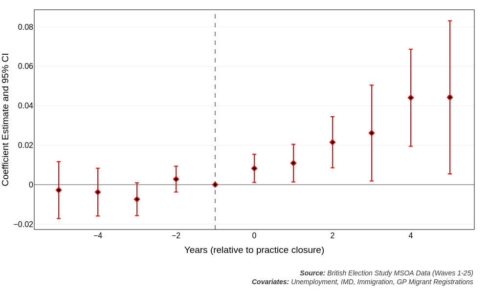

**Note:** Independent replication using the BES panel (~30,000 respondents, 2014–2023). Results consistent in direction and timing. Effects peak at ~4pp approximately 4 years post-closure — slightly larger than USOC estimates.

## Step 3: How? Populist Right Links NHS Decline to Immigration

> Two Empirical Measures of Linkage in Populist Right Communication

**Type 1: Co-occurrence only**

“And I again I think that Britain is broken. Maybe the prime minister doesn’t realize this, but the vast majority of us realize the **NHS** is not working as it was intended and needs radical reform. Of course, one of the problems is that 7.2 million **foreign born** people have signed up with **GPs** in the last 10 years alone. Can you believe that? 7.2 million people extra. So don’t be surprised if there’s a big cue to get, you know, an appointment with your local GP.”

Immigration and NHS co-occur; no explicit causal connector — not classified as direct causal linkage.

**Type 2: Co-occurrence + causal connector**

“We’ve got 10,000 people a week coming into Britain, half a million coming in every year, nearly 5 million economic **migrants** in the space of the last 10 years. It is totally unprecedented, it has never happened before [and] the effects are obvious in every single part of our national life with massive **strain on** the **NHS**.”

UKIP (2013): “strain on” is an explicit causal connector in close proximity — classified as direct causal linkage.

**Note:** Farage (Type 1) vs. UKIP 2013 video (Type 2). Both are captured as co-occurrences; only Type 2 is additionally classified as containing an explicit causal link.

## Step 3: Populist Right Links NHS Decline to Immigration

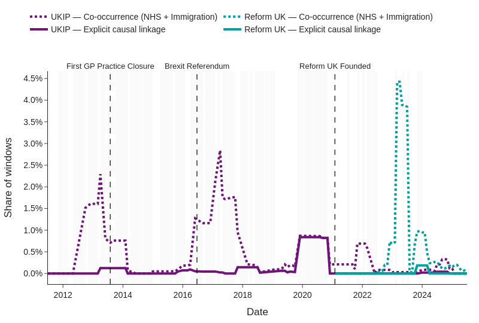

## Step 3: Immigration Moderates the Effect

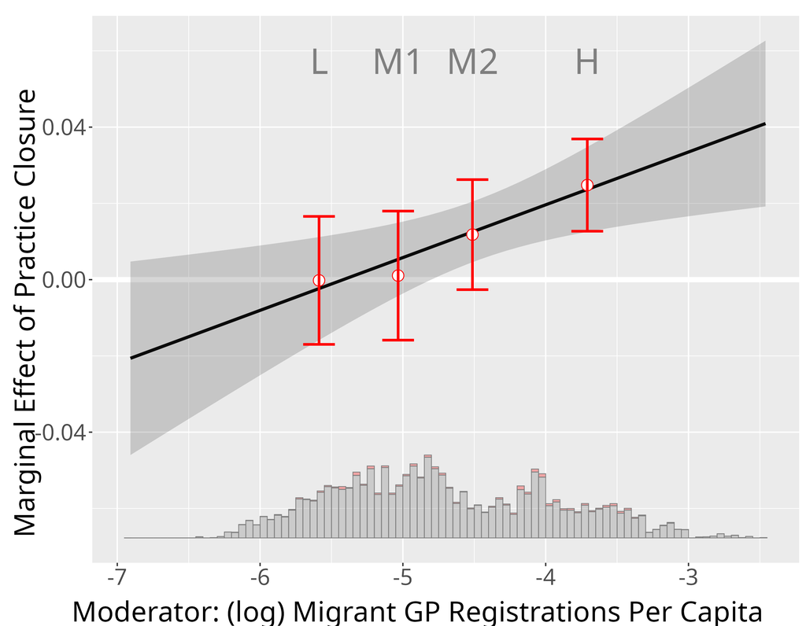

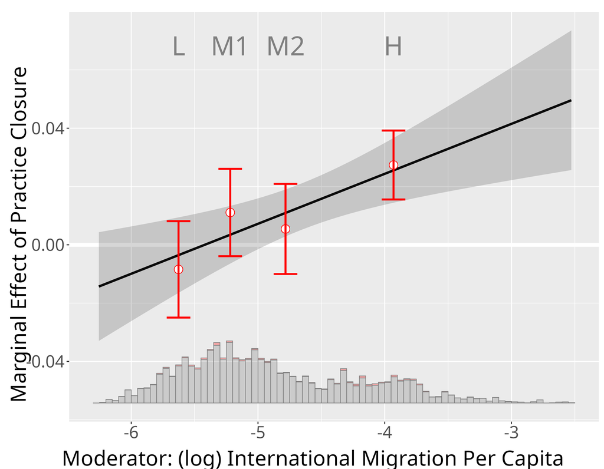

**Note:** Conditional average treatment effects (binning estimator, Hainmueller, Mummolo, and Xu (2019)). Effects of closures on populist right vote are significantly larger in high-migration areas (both migrant GP registrations and general immigration). Distributions of treated (red) and control (gray) areas are well-balanced.

# Robustness Checks

**Alternative Estimation**

**Sample Restrictions**

- **Not-yet-treated only** as control group: results robust (N=66,467; noisier due to smaller sample)
- **Re-opening practices**: including as treated or as control — results unchanged

**Placebo & Falsification Tests**

- **Placebo outcomes**: no detectable effects of closures on financial situation, future financial expectations, income satisfaction, or job satisfaction
- **No residential sorting**: closures do not increase preferences or plans to relocate — ruling out Tiebout-style exit
- **Vote intention vs. actual vote**: strong correspondence with realized vote shares in 2015, 2017 and 2019 elections

**Moderation specificity**

- Immigration moderates effects **only for the populist right** — null or negative interaction for all other party families

# Conclusions

- **Causal evidence** that GP practice closures increase populist right vote intention by **2–4 percentage points**, effects persisting for at least 4–5 years
- Effects are **specific to the populist right** — no comparable gain for Labour or other opposition parties
- **Immigration amplifies the effect**: stronger in areas with higher migrant inflows and migrant GP registrations — consistent with populist right messaging
- **Key Contribution**: Public service decline is a distinct, underappreciated driver of populist right support
  - Beyond economic and cultural backlash: *state performance matters*
  - Particularly consequential where the populist right can credibly link service decline to demographic change
  - Policy implication: maintaining public service quality is a first line of defence against populist mobilisation

# References

Athey, Susan, Mohsen Bayati, Nikolay Doudchenko, Guido Imbens, and Khashayar Khosravi. 2021. “Matrix Completion Methods for Causal Panel Data Models.” *Journal of the American Statistical Association* 116 (536): 1716–30.

Besley, Timothy. 2020. “State Capacity, Reciprocity, and the Social Contract.” *Econometrica* 88 (4): 1307–35.

Hainmueller, Jens, Jonathan Mummolo, and Yiqing Xu. 2019. “How Much Should We Trust Estimates from Multiplicative Interaction Models? Simple Tools to Improve Empirical Practice.” *Political Analysis* 27 (2): 163–92.

Levi, Margaret. 1988. *Of Rule and Revenue*. University of California Press.

Liu, Licheng, Ye Wang, and Yiqing Xu. 2022. “A Practical Guide to Counterfactual Estimators for Causal Inference with Time-Series Cross-Sectional Data.” *American Journal of Political Science*.

Margalit, Yotam. 2019. “Economic Insecurity and the Causes of Populism, Reconsidered.” *Journal of Economic Perspectives* 33 (4): 152–70.

Mudde, Cas. 2016. *The Populist Radical Right: A Reader*. Taylor & Francis.

Norris, Pippa, and Ronald Inglehart. 2019. *Cultural Backlash: Trump, Brexit, and Authoritarian Populism*. Cambridge University Press.

Sun, Liyang, and Sarah Abraham. 2021. “Estimating Dynamic Treatment Effects in Event Studies with Heterogeneous Treatment Effects.” *Journal of Econometrics* 225 (2): 175–99.

# Appendix

## A1: Four Model Specifications — BES

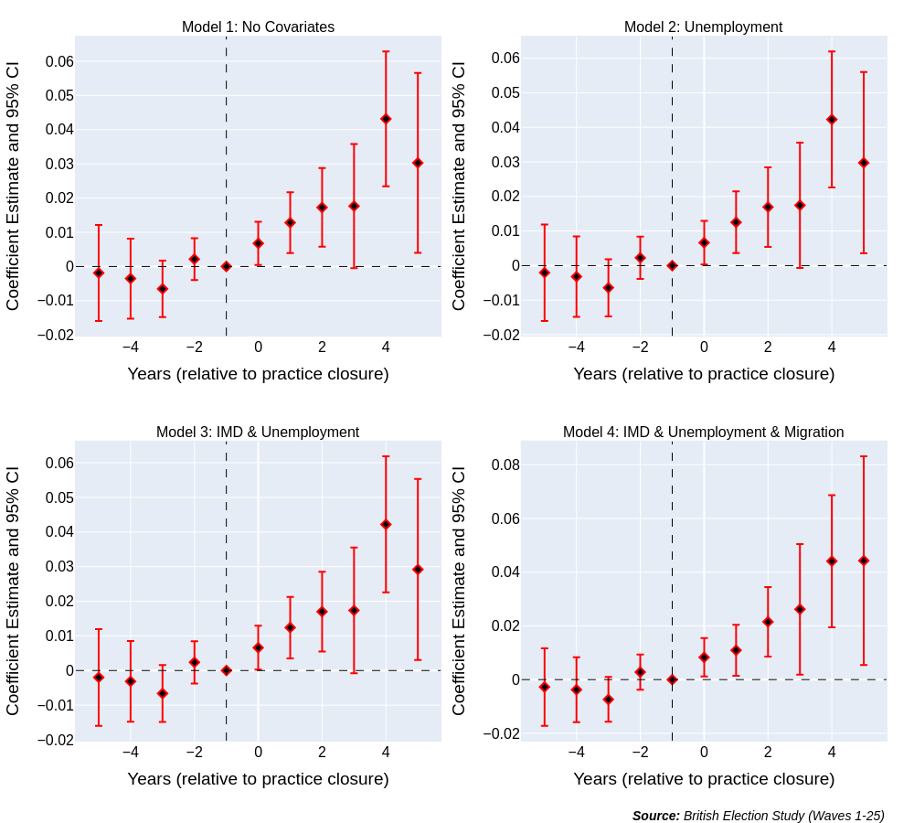

## A2: Four Model Specifications — USOC

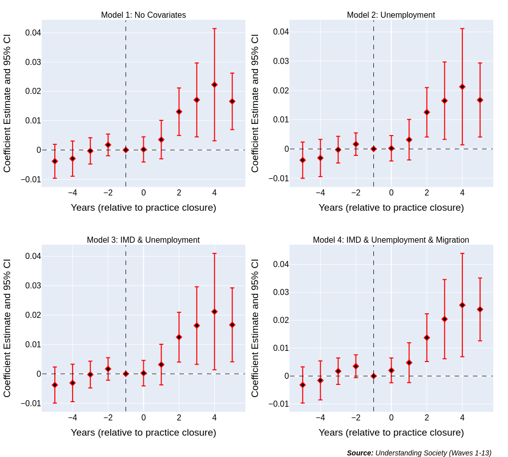

**Note:** As above but using the USOC panel. All four model specifications yield consistent positive effects of closures on populist right vote intention.

## A3: Effects on All Party Families

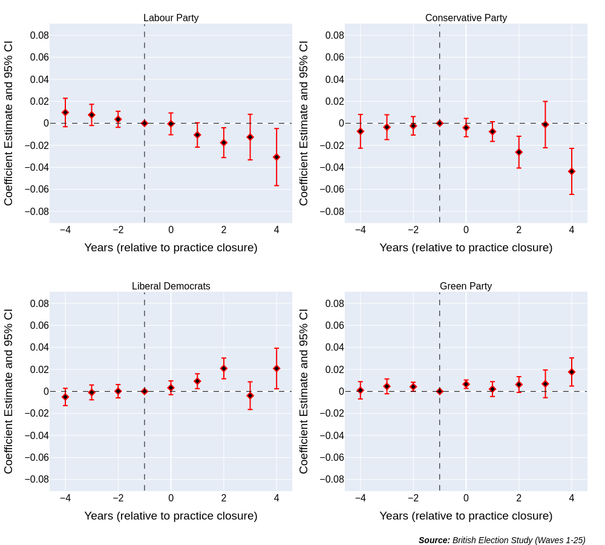

**Note:** GP closures reduce support for mainstream parties (Labour, Conservative) but the largest and most consistently estimated effect is for the populist right. No offsetting gain for Labour.

## A4: Not-Yet-Treated as Control Group

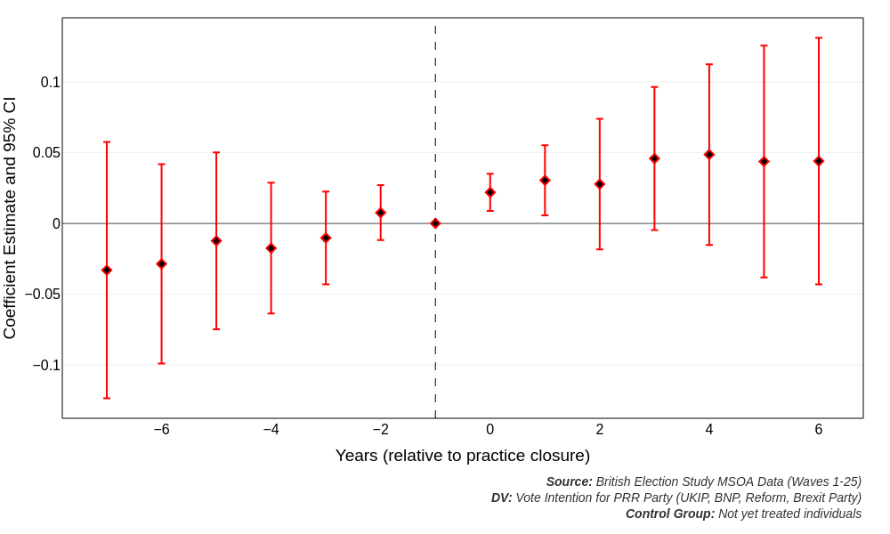

## A5: Placebo Outcome Tests

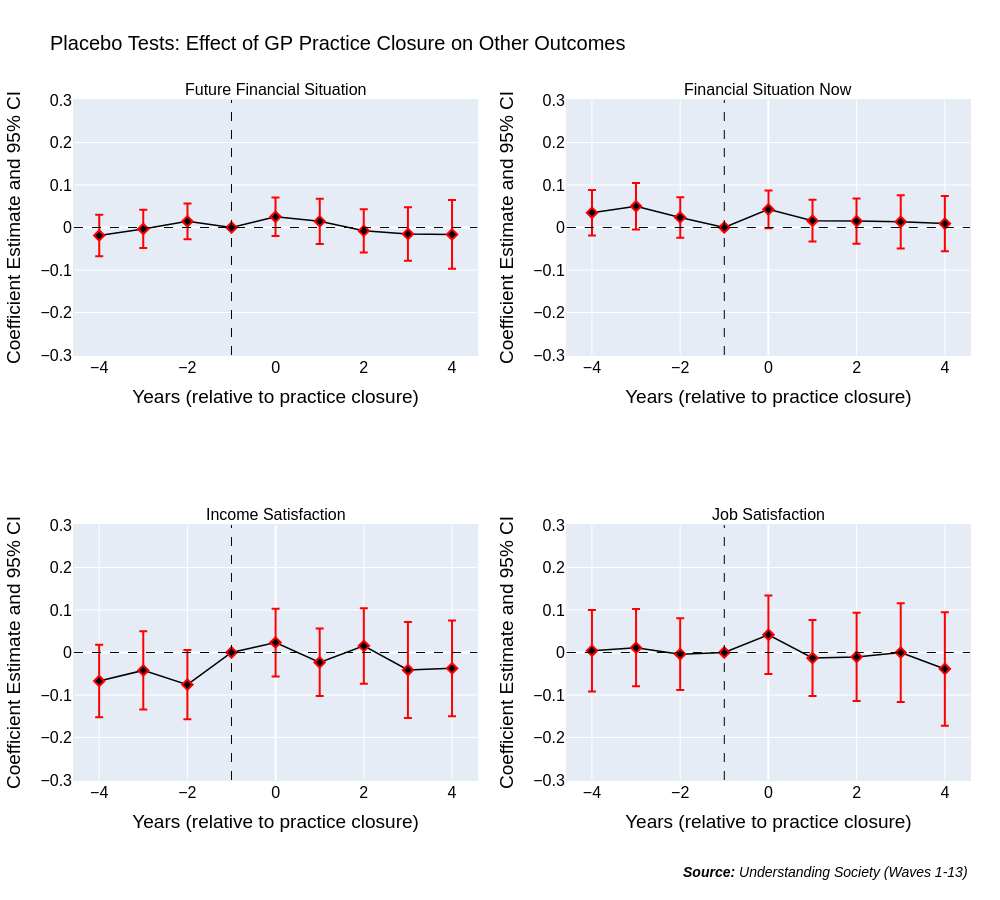

**Note:** Placebo tests replacing the populist right vote outcome with financial situation, future financial expectations, income satisfaction, and job satisfaction. No statistically detectable effects, supporting the specificity of the main results.

## A6: No Residential Sorting

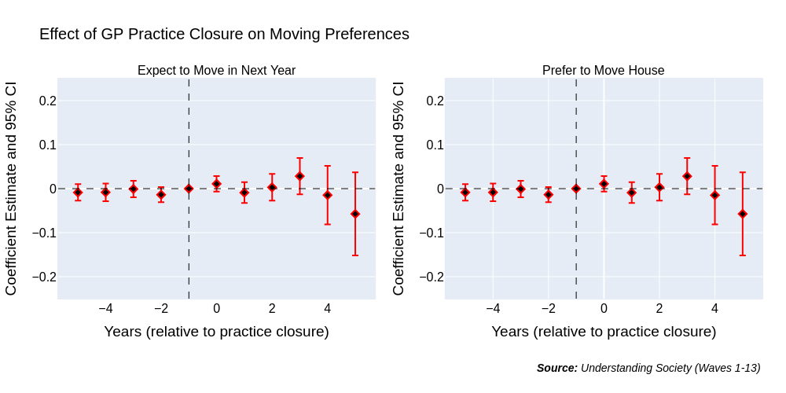

**Note:** Effects of GP closures on preferences and expectations to move house. No detectable effects, ruling out Tiebout-style exit responses that could confound the main estimates.

## A7: Vote Intention vs. Actual Vote Share

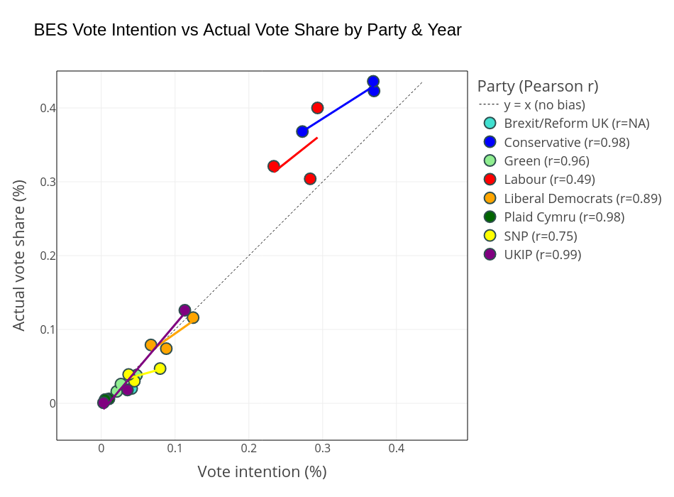

**Note:** Correspondence between BES vote intention and realized vote shares in the 2015, 2017 and 2019 General Elections. High correlation validates the use of vote intention as a proxy for electoral behaviour.

## A8: Press Release Linkage — NHS and Immigration

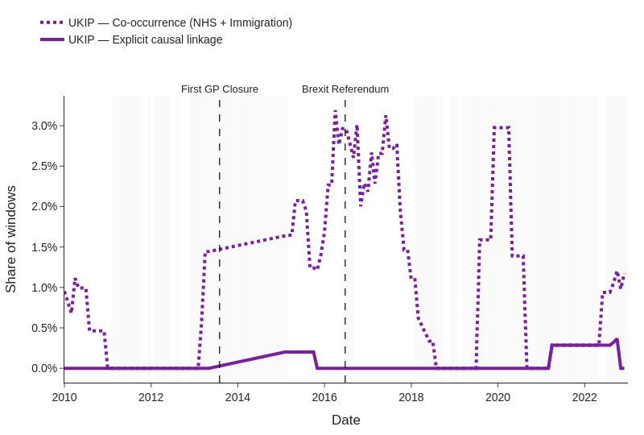

## A9: Patient Satisfaction — Matrix Completion Replication

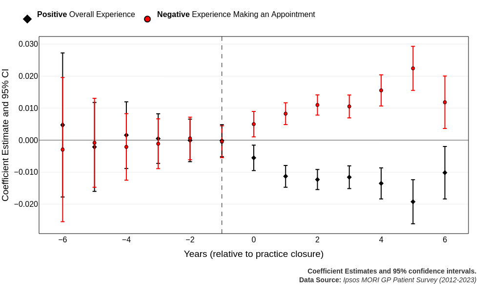

**Note:** Matrix completion replication of the patient satisfaction results. Estimates are consistent with the primary Sun-Abraham event study, providing additional confidence in the manipulation check.

## A10: Populist Right Vote — Matrix Completion Replication (USOC)

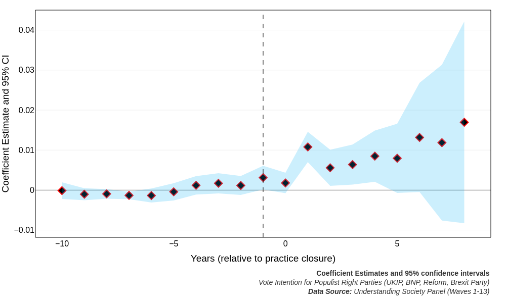